# Evaluating fit of BBA model

Hauke Licht

2019-04-12

```r
# set seed
this_seed <- 1234
set.seed(this_seed)


# set the file path
file_path <- file.path("~", "switchdrive", "Documents", "work", "phd", "methods", "crowd-sourced_annotation")

# load required namespaces

# data manipulation
library(dplyr)
library(purrr)
library(tidyr)
library(stringr)
# stats
library(extraDistr)
library(rjags)
# plotting
library(ggplot2)
library(ggridges)
library(gridExtra)
library(grid)

# define helpers

# from codings data frame, get list that can be passed to 'code::model's data argument when fitting the BBA model
get_codings_data <- function(codings.df) {

  out <- list()

  out$N <- length(unique(codings.df$item))
  out$M <- length(unique(codings.df$coder))
  out$J <- length(codings.df$judgment)
  out$y <- codings.df %>%
    arrange(item, coder) %>%
    select(item, coder, judgment)

  return(out)
}


# Function getting parameter estimates from 'coda::mcmc.list' object and returns them in a tidy dataframe
get_mcmc_estimates <- function(fit.obj, params, use.regex = TRUE){

  if (!inherits(fit.obj, "mcmc.list"))
    stop("`fit.obj` must be a 'mcmc.list' object")

  # test number of chains (equals No. top-level list elements)
  if ( (n_chains <- length(fit.obj)) == 0)
    stop("`fit.obj` has zero length")

  # get parameters contained in fit object
  these_params <- colnames(fit.obj[[1]])

  # get index positions of parameters to be obtained
  if (use.regex) {
    idxs <- which(grepl(params, these_params))
  } else {
    if (any((miss_params <- !params %in% these_params)))
      warning(
        "The following `params` are not contained in `fit.obj`: ",
        paste0("'", params[miss_params], "'", collapse = ", ")
      )
    idxs <- which(these_params %in% params)
  }

  # obtain parameter estimates in tidy data frame
  suppressWarnings(
    purrr::map_df(these_params[idxs], function(param, obj = fit.obj){
      purrr::map_df(1:n_chains, function(c, o = obj, p = param) {
        tibble::tibble(
          parameter = param
          , chain = c
          , est = o[[c]][, p]
        ) %>%
          dplyr::mutate(iter = dplyr::row_number())
      })
    })
  )
}
```

## Goal

The goal of this note is to implement and validate the Beta-Binomial by Annotator (BBA) model proposed by Carpenter (2008) in JAGS using R. This model is designed to obtain estimates of items class membership from a set of multiple (human) judgements per along a binary coding scheme. Human judgments are also referred to as annotations or codings.

I first introduce notation and present the model as discribed in Carpenter’s original article and illustrate prior choices. I then simulate binary codings data following the instructions specified in Carpenter (2008, 16 and 19). In the final section, I then evaluate whether the model allows to recover the simualted parameter values. I find that it does so quiet well for the prevalence of positive instances, and the hyperparameters governing coder-specific parameters. Surprisingly, however, and in contradiction to what Carpenter reports for simulated data generated, the model performs poorly in recovering the true simulated coder-specific abiltiy parameters. Morover, the model quiet confidently misclassifies a sizeable amount of items. This results in an accouracy of only ~70%.

## Implementation

### Notation

The setup can be described as a four-tuple $\langle\mathcal{I}, \mathcal{J}, \mathcal{K}, \mathcal{Y}\rangle$:

- $\mathcal{I}$ is the set of $i \in 1,\ \ldots ,\ n$ distributed for coding/annotation,
- $\mathcal{J}$ is the set of $j \in 1,\ \ldots ,\ m$,
- $\mathcal{K}$ is the set of $k \in \{0, 1\}$ defined by the categorical coding scheme, and
- $\mathcal{Y}$ is the set of (or codings) $y_{i,j} \in \{0, 1\}$ recorded for item $i$ by coder $j$.

In total, we have $d = n \times m$ judgments. It is provided that $\mathcal{Y}$ contains at least one judgment per item, that is, $|\mathcal{Y}_i| \geq 1\ \forall\ i \in \mathcal{I}$, and that $|\mathcal{Y}_i| \geq 2\ \forall\ i \in \mathcal{I}' \subset \mathcal{I}$ and $\mathcal{I}' \neq \emptyset$. Moreover, no coder judged an item more than once. When each item is judged by each coder we refer to the codings data as a *complete panel*. When each item not is judged by each coder we refer to the codings data as a *panel with missingness*.

### The Model

Importantly, while coders’ judgments of items are observed, items’ true classes $c_i \in \mathcal{K}$ are unknown *a priori* for all $i = 1,\ \ldots,\ n$. In this setup, a classification of items into classes obtained from a set of judgments $\rho(\mathcal{Y}) \Rightarrow \mathcal{C}$ is called a *ground truth labeling*.

Given codings data, such a ground truth labeling can be obtained by estimating the following Bayesian hierarchical model (Carpenter 2008, Figure 3):

$$\begin{align*}
c_i &\sim\ \mbox{Bernoulli}(\pi)\\
\theta_{0j} &\sim\ \mbox{Beta}(\alpha_0 , \beta_0)\\
\theta_{1j} &\sim\ \mbox{Beta}(\alpha_1 , \beta_1)\\
y_{ij} &\sim\ \mbox{Bernoulli}(c_i\theta_{1j} + (1 - c_i)(1 - \theta_{0j}))\\
{}&{}\\
\pi &\sim\ \mbox{Beta}(1,1)\\
\alpha_0/(\alpha_0 + \beta_0) &\sim\ \mbox{Beta}(1,1)\\
\alpha_0+\beta_0 &\sim\ \mbox{Pareto}(1.5)\\
\alpha_1/(\alpha_1 + \beta_1) &\sim\ \mbox{Beta}(1,1)\\
\alpha_1+\beta_1 &\sim\ \mbox{Pareto}(1.5)
\end{align*}$$
where

- $c_i$ is the class of statement $i$,
- $\theta_{0,j}$ is coder $j$’s specificity (true-negative detection ability), and $\theta_{1,j}$ is her sensitivity (true-positive detection ability),
- $y_ij$ is coder $j$’s observed judgement of item $i$,
- $\pi$ is the prevalence of the positive class, and
- $\alpha_0/(\alpha_0 + \beta_0)$ ($\alpha_1/(\alpha_1 + \beta_1)$) is the mean of the Beta hyper-distribution governing coders’ specificities (sensitivities) and $\alpha_0 + \beta_0$ ($\alpha_1 + \beta_1$) is the scale of this distribution.

Carpenter (2008) refers to this model as the Beta-Binomial by Annotator (BBA) model.[^1] As already touched upon above, the only data we observe is coders’ judgments of items into classes. A coder’s individual judgment is modeled as a draw from a Bernoulli distribution. Specifically, $p$, the parameter governing the Bernoulli distribution, is set to the coder’s sensitivitiy if the item’s true class, $c_i$, equals 1, and to the coder’s specificity otherwise. The item’s true class, in turn, follows a Bernoulli distribution governed by $pi$, which in turn is given a flat beta prior. Similarly, a coder’s specifiticty $\theta_{0j}$ (sensitivity $\theta_{1j}$) is a draw from a Beta distribution that itself is governed by $\alpha_0$ ($\alpha_1$) and $\beta_0$ ($\beta_1$), which, in turn, are given flat priors. Specifically, means of the Beta-distributions of coders’ specificity and sensitivity are given a flar Beta prior, and the inverse square scales $1/(\alpha_.+\beta_.)^2$ of the Beta-distributions of coders’ specificity and sensitivity are given a uniform prior, which are expressed as Pareto priors on the scales.

These priors look as follows:

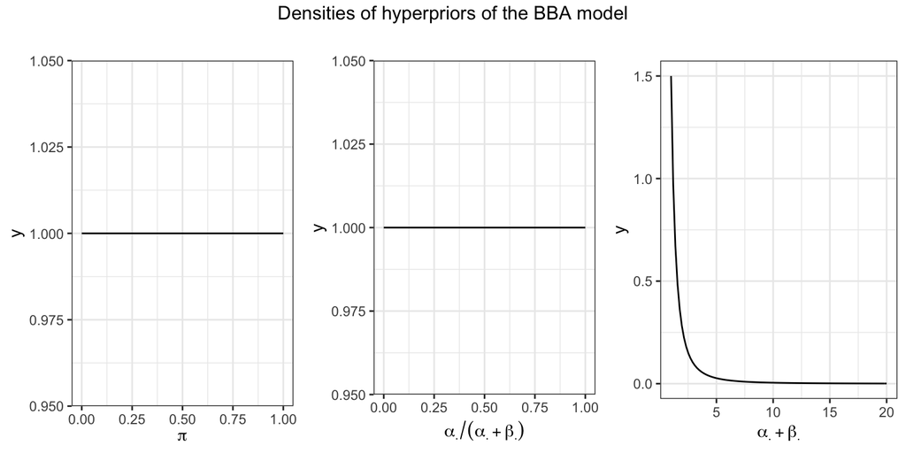

The latter two priors can also be inspected with regard to what priors they induce on $\alpha_.$ and $\beta_.$, respectively. To do so, I sample 1000 pairs from correspondingly parameterized distributions and compute $\alpha^{sim}$ and $\beta^{sim}$ values from each pair.

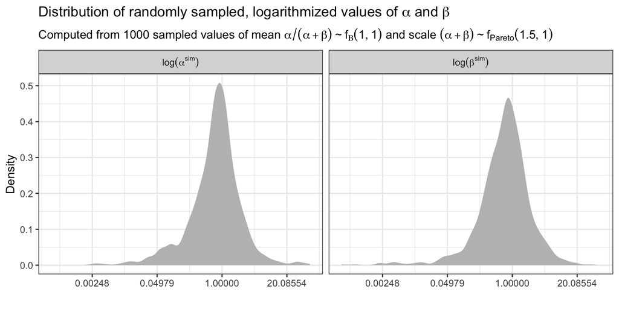

Next, I use the sampled $\alpha^{sim}$ and $\beta^{sim}$ values to obtain draws from a correspondingly parameterized Beta distributions. This yields the following empirical distribution:

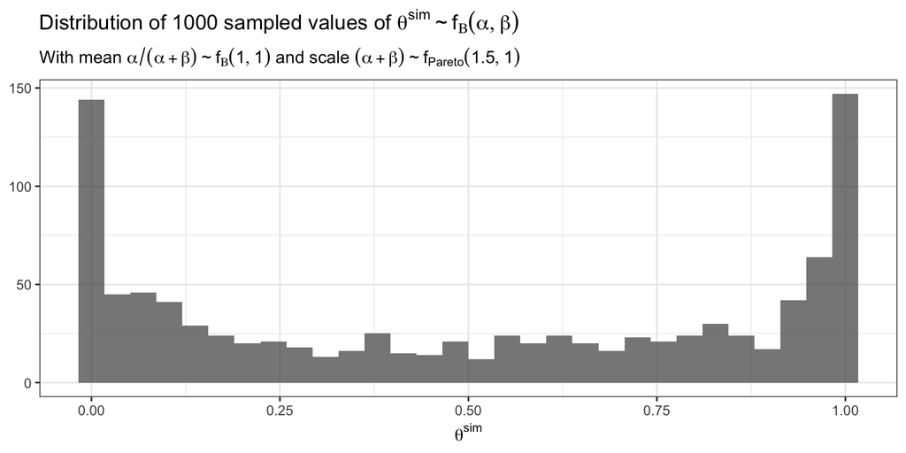

What these hyperprior choices induce is thus a push of coder ability estimates to the extremes of perfect specificity (sensitivity) and perfectly negatively-correlated specificity (sensitivity), respectively.

## Validation

### Data generation

```r
# simulation parameters
n_items <- 1000
n_coders <- 20
missingness_rate <- .5

# data generation parameters
pi <- .2
alpha0 <- 40
beta0 <- 8
alpha1 <- 20
beta1 <- 8

# sample items' classes
sim_item_classes <- as.integer(rbernoulli(n = n_items, p = pi))

# sample coders' ability parameters
sim_theta0 <- rbeta(n = n_coders, shape1 = alpha0, shape2 = beta0)
sim_theta1 <- rbeta(n = n_coders, shape1 = alpha1, shape2 = beta1)

# for each item i
sim_codings <- map_df(1:n_items, function(i){

  # sample ~10 coders who judge the item's class
  idxs <- sample(1:n_coders, ceiling(n_coders*(1-missingness_rate)))

  # for each coder in the sample,
  y_i <- map_int(idxs, function(idx) {
    # generate coder j's judgment given item i' s 'true' class:
    #  - if the 'true' class is positive, j classifies it as positive with probability theta_{j1}
    #  - if the 'true' class is negative, j classifies it as negative with probability theta_{j0}
    rbernoulli(1, p = sim_item_classes[i]*sim_theta1[idx] + (1 - sim_item_classes[i])*(1 - sim_theta0[idx]) )
  })

  # gather data and return
  tibble(
    # the item index (ID)
    item = i
    # coders indices (IDs)
    , coder = idxs
    # simulated judgments
    , judgment = y_i
    # item i's 'true' class
    , true_class = sim_item_classes[i]
  )
})

sim_codings <- list(
  codings = sim_codings
  , abilities = list(
    theta0 = sim_theta0
    , theta1 = sim_theta1
  )
)
```

To examine whether the model is able to recover correct parameter values, I follow the instructions Carpenter gives to simulate a panel with missingness of codings generated by 20 coders for 1000 items with a missingness rate of 0.5. Items true classes are drawn from a Bernoulli distribution with $pi = .2$. In expectation, we thus have four times as many negative as positive items. Annotators’ specificity and sensitivity parameters $\theta_{.0}, \theta_{.1}$ are drawn from $f_{\text{Beta}}(\alpha_0, \beta_0)$ with $(\alpha_0, \beta_0) = (40, 8)$ and $f_{\text{Beta}}(\alpha_1, \beta_1)$ with $(\alpha_1, \beta_1) = (20, 8)$, respectively. The probability density functions (PDFs) of these distributions look as follows:

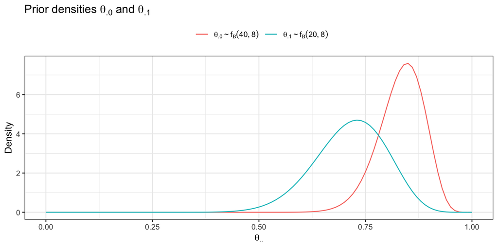

Coders’ simulated (true) abilities parameter values scatter nicely, so that it is ensured that the simulated judgments are generated by a population of coders with mixed ability profiles (mind axes scales):

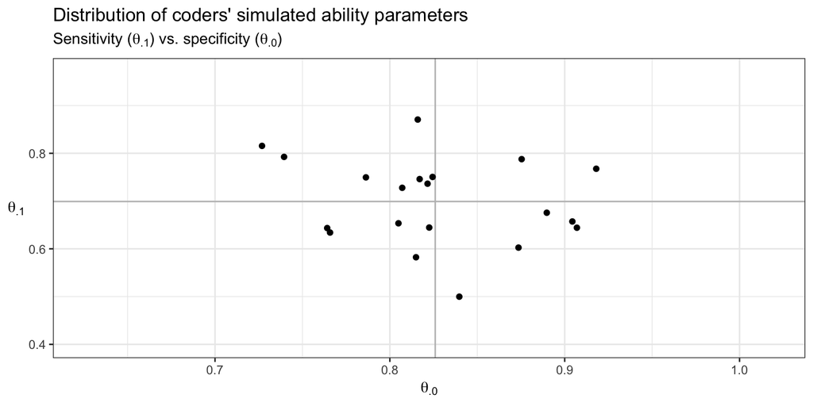

This yields 10 per item obtained from a random subsample of unique coders.

Knowing items true classes allows to compute coders empirical performance. As the following plot illustrates, coders vary also in their observed performance:

```r
# inspect coders' performance
obs_performance <- sim_codings$codings %>%
  group_by(coder) %>%
  summarise(
    n_judgments = n_distinct(item)
    , accuracy = sum(judgment == true_class)/n_distinct(item)
    , tp = sum(judgment == 1 & true_class == 1)
    , fn = sum(judgment == 0 & true_class == 1)
    , fp = sum(judgment == 1 & true_class == 0)
    , tn = sum(judgment == 0 & true_class == 0)
    , TPR = tp / (tp + fn)
    , TNR = tn / (tn + fp)
  )
```

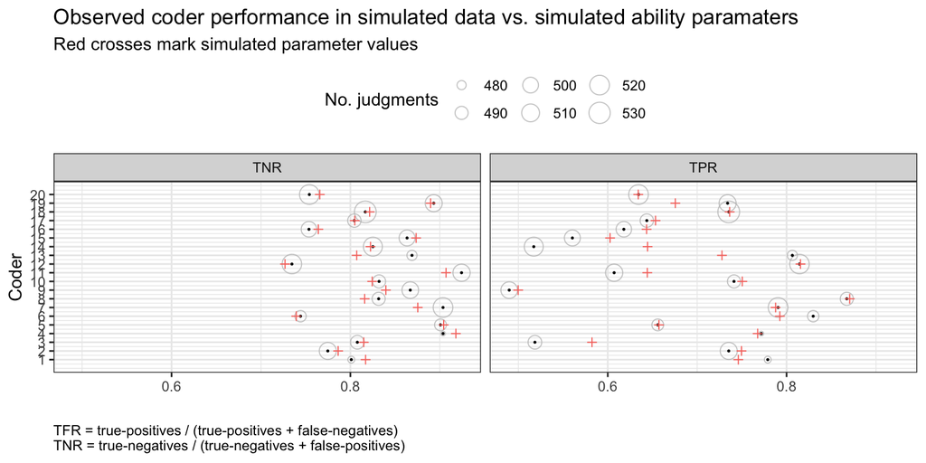

Summarizing this information confirms that there is no systematic deviation of observed from simulated abilities:

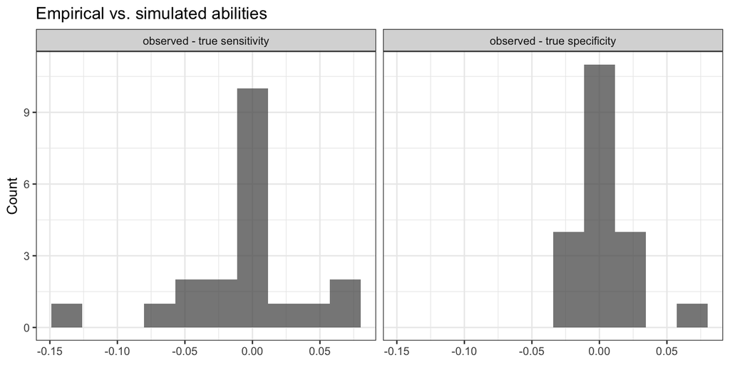

Note also that the larger magnitude and mass of deviations of the observed sensitivities is due to the fact that in expectation we have four times more negative items than positive ones, so that coder’s true-negative detection rates can be computed with higer precision than their true-positive detection rates.